# CV - Module Project Part-5 Model Maintenance and Monitoring Strategies

### **ML Infrastructure:**

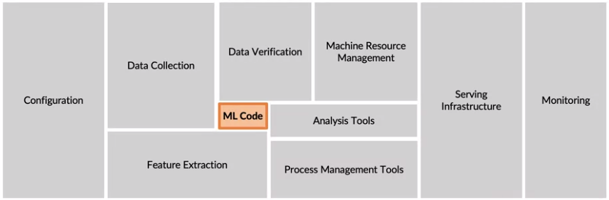

### **ML Development Cycle:**

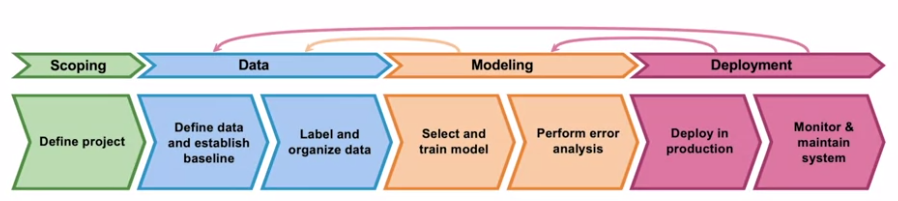

### Monitor

Maintenance of ML and DL models is an integral part of the ML production pipeline and it is quite crucial to maintain it for actually helping maintain the usability, accuracy of the modeol. So, we caon follow the following strategies to maintain and monitor the classifier:

- **Check for Training/serving skew**: When the distribution of the testing data used to train is different than the real-world production images
- **Check for Concept drift**: changes in $P(Y|X)$ which is the underlying probabilities. Can be gradual, sudden or recurring (seasonal). Given, that seedlings will continue to be of the same types and have the same type of characteristics. We need not worry about this for our model.
- **Check for Data drift**: changes in $P(X)$, also called feature drift, population shift or covariate shift. This might happen if the testing data or out-of-sample data comes from a different distribution of different seedlings or some minor differnces in how the images are taken, when they're taken ..etc., So, It's crucial we monitor for data drift
- **Check for Model drift**: Monitor the accuracy of real-world dataset to ascertain whether the model has to be re-trained or improved upon to maintain or imporove the accuracy from the previous iteration.
- Check if data change is gradual or is it susceptible to shocks?

In the case of radical shifts, models break. Immediately after the shock you could consider pausing the model until more new data is collected, and falling back to heuristic models.

### Retrain

So if we have model any scenario accuracy decay or data drift. We could retrain the model in such a case:

- Add new data sources and datasets, if available
- Retrain the model using all available data, both before and after the shock.
- Use everything, but assign higher weights to the new data so the model gives priority to the recent patterns.
- If enough new data is collected, you can simply train only with the post-shock data.
- Domain adaptation techniques, try to get more features for the seedlings if requried.
- Try entirely new architectures.
- Build a new CNN or better CNN.

### Monitoring Dashboard

We can think of all the things that can go wrong, and design metrics or statistics that help you spot those issues for each of the steps of your machine learning pipeline. Set alarm thresholds for these metrics.

- **Software metrics**: memory, compute, latency, throughput, server load
- **Input data metrics**: average pixel brightness (to make sure we're not getting completely dark images ..etc.,), colorspace of images to check green seedlings are actually present in the fram of images.
- **Output data metrics**: Accuracy, Precision, Recall, Weighted F1, Confusion Matrix

Using such a dashboard, we can monitor for model performance and intervene, generate alerts in case of model failures and take appropriate steps to retrain, debug and redeploy the Image Classifier model.

### Active Learning

Finally, we could train and productionize a model that has the ability to actively learn while doing inference on test data.